# 20th Feb

## Further Development of Corrected Coverage Method

- If all the user wants to do is to estimate the corrected coverage, then we can just simulate and average the binary covered column of these simulated credible sets.
- If we can fit a model, then we choose a GAM. We tried logistic regression but it wasn’t bendy enough and we don’t have enough data to fit a random forest (these aren’t smooth and need lots of data at specific points on the x axis to calculate the average and to fit a line through - only accurate estimates at these dense x regions).
- So far, our package provides users with an accurate coverage probability. Would be good if we could extend the package such that the user is provided with a new ‘required threshold’ value that they should use in the credset function to obtain a credible set with the required true coverage.

### Contents

1. Does our method even fit a GAM?
2. New GAM fitting ideas (to ALL data)
3. Problem: Too many data points
4. Quicker GAM fitting methods
5. Next Steps

### How often is a GAM actually being fitted?

```r
### corr.maxz0 method
colMeans(res1)
```

```
##      good   warning     error
##   0.00000   4.10198 195.84208
```

```r
### corr.muhat.ave method
colMeans(res2)
```

```
##       good    warning      error
##   0.000000   3.264356 196.679703
```

- I tried to fit a GAM for the simulated credible sets for each SNP considered causal (5000 data points for each GAM). If the GAM could be fit with no problem, then my code returns ‘good’, similarly for ‘warning’/‘error’. The figures above are the colMeans for the simulations. On average 195/200 GAMs fitted (each SNP causal), an error is returned.
- I told my original simulations to just average the covered column is ANY out of the 200 GAMs (each SNP considered causal) returned an error (as these returned NaNs in the `final` vector and I couldn’t average).
- This means that a GAM wasn’t actually being fit at all! I was just averaging the covered column.
- We didn’t identify this earlier as we were working on lower power scenarios.

**Try fitting a GAM to the cumulative pps (rather than the size of the cred set). I.e. get 200 data points for everyone 1 in original method.**

BUT for just 100 simulations for each snp causal, that is $100\times 200\times 200=4e+06$ data points to fit a gam to which `mgcv::gam`` struggles with. I later explore variations for quicker GAM fitting.

### Fitting GAM to Whole Data

**Try fitting a GAM to the cumulative pps (rather than the size of the cred set). I.e. get 200 data points for everyone 1 in original method.**

- For each simulated posterior probability system for each variant considered causal a GAM is fitted for `covered` vrs `cpp` (cumulative probabilities) where the variants have been sorted into descending order. This GAM is then used to predict the coverage probability at the claimed coverage.
- We could also consider a backwards approach, whereby the corrected target (claimed coverage on x axis) is read off for some target coverage value. For example, if a user wanted a credible set with 90% corrected coverage, then we could tell them that they need to use a ‘required’ threshold value of X. They can then use this value as the threshold parameter in the `credsets` function to obtain their new credible set with the desired corrected coverage.
- A problem with this is that the data from the fitted GAM often looks like this,

```r
test <- readRDS("/Users/anna/Google Drive/PhD/feb/credsets/check_errors/test.RDS")
test
```

```
##      cpp             y
## 1   0.00  0.000000e+00
## 2   0.01  0.000000e+00
## 3   0.02  0.000000e+00
## 4   0.03  0.000000e+00
## 5   0.04  0.000000e+00
## 6   0.05  0.000000e+00
## 7   0.06  0.000000e+00
## 8   0.07  0.000000e+00
## 9   0.08  0.000000e+00
## 10  0.09  0.000000e+00
## 11  0.10  0.000000e+00
## 12  0.11  0.000000e+00
## 13  0.12  0.000000e+00
## 14  0.13  0.000000e+00
```

[output cut: 87 more lines]

```r
approx(x = test$cpp, y = test$y, xout = 0.9)$y
```

```
## [1] 5.369007e-07
```

```r
approx(x = test$cpp, y = test$y, xout = 0.95)$y
```

```
## [1] 1
```

- So for example, if we want a 90% credible set, it will tell us to use a threshold of 5.369e-07.
- Another problem is that in a lot of cases, a GAM cannot be fitted because the covered column is all 1s.

### Too Many Data-points

- Fit a GAM to all the data points, so for 5000 simulations for each SNP causal there would be `5000*200*200` data points to fit a GAM to.
- The `mgcv::gam` function cannot handle this, in fact, struggles with `nrep=100`.
- There is another method, `mgcv::bam` which is for large datasets. “The fitting methods used by gam opt for certainty of convergence over speed of fit. bam opts for speed.”
- More info [here](https://stat.ethz.ch/R-manual/R-patched/library/mgcv/html/gam.convergence.html)
- Other ideas:
1. Try `optimizer = bfgs` option in `gam`.
2. Change smoothing basis to `bs = "cr"` in `gam`. (The default thin plate regression spline is costly for large datasets).
- I investigated these other methods, applying them all to the same data. My workflow is described below:
1. Simulate some data, that is, follow the standard steps and obtain `nrep*nsnp` data.frames. Here we consider 200 snps and simulate 15 credible sets for each SNP considered causal.
2. Each of these data.frames has a row for the cusum of the ordered pps and a covered column (all 0s until hit the CV, then 1).
3. `rbind` all of these to form one big data set with `nrep*nsnp*nsnp=15*200*200=6e+05` data points.
4. Add a column for `logit(cusum)`.
5. Fit a GAM using each of the following methods:

```r
m.gam <- mgcv::gam(cov ~ s(logitcpp), data = d, family = "binomial")
m.bam <- mgcv::bam(cov ~ s(logitcpp), data = d, family = "binomial")
m.bfgs <- mgcv::gam(cov ~ s(logitcpp), data = d, optimizer = c("outer","bfgs"), family = "binomial")
m.cr <- mgcv::gam(cov ~ s(logitcpp), data = d, bs = "cr", family = "binomial")
```

6. I then use each of the models to predict the some claimed coverage data.

```r
x <- seq(0.0001, 0.999999, by = 0.01)
p.gam <- invlogit(predict(m.gam, newdata = data.frame(logitcpp = log(x))))
p.bam <- invlogit(predict(m.bam, newdata = data.frame(logitcpp = log(x))))
p.bfgs <- invlogit(predict(m.bfgs, newdata = data.frame(logitcpp = log(x))))
p.cr <- invlogit(predict(m.cr, newdata = data.frame(logitcpp = log(x))))
```

7. The output is shown below, note that there is really no discrepencies between the model fit for each model.

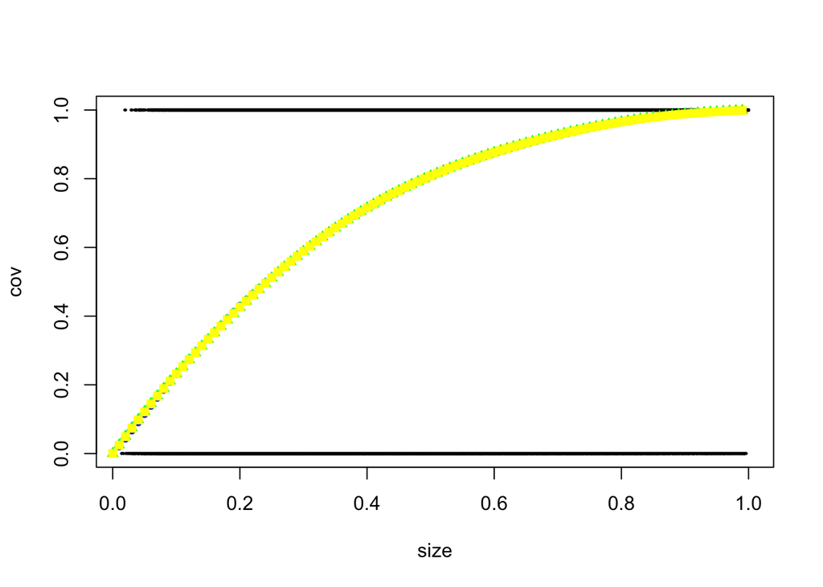

```r
data <- readRDS("/Users/anna/Google Drive/PhD/feb/credsets/check_GAM/testdata.RDS")

d <- data$d

plot(d$cpp, d$cov, xlab="size", ylab="cov", cex=0.2)

points(data$x, data$p.gam, col="red", pch=18) # normal gam
points(data$x, data$p.bam, col="blue", pch=20) # bam
points(data$x, data$p.bfgs, col="green", pch=17) # optimizer=bfgs
points(data$x, data$p.cr, col="yellow", pch=15) # bs=cr
```

- We could then potentially use the fastest one of these methods to back estimate what threshold value would be required to obtain a credible set with the required coverage. Using something like this,

```r
# to have 95% coverage you need to use this value to obtain your credible set
approx(x = data$cpp, y = data$y, xout = 0.95)$y
```

### Which GAM Method?

- I am running a simulation to report the time taken to fit each of the GAMs for varying parameters.

```r
NN=sample(c(5000,40000),1)
OR=sample(c(1.05,1.2),1)
thresh=sample(c(0.6,0.95,0.99),1)
```

- I will do this for `nrep=15`, `nrep=20`, `nrep=50`.

```r
library(data.table)
```

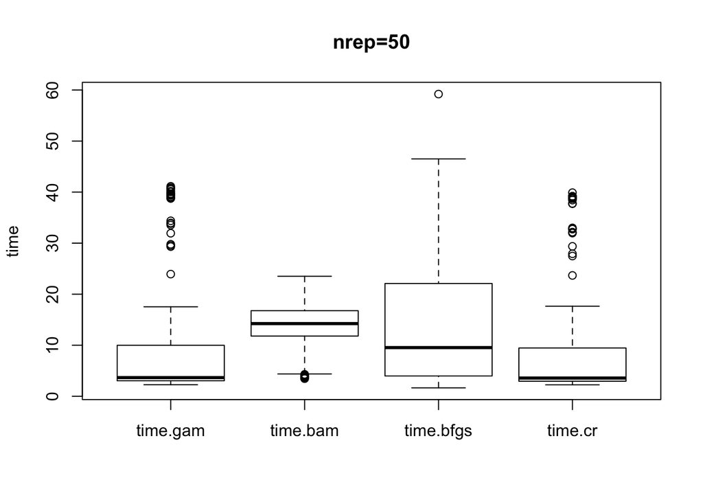

```r
library(ggplot2)
sims50 <- as.data.frame(readRDS("/Users/anna/Google Drive/PhD/feb/credsets/check_GAM/fullsims50.RDS"))
sims20 <- as.data.frame(readRDS("/Users/anna/Google Drive/PhD/feb/credsets/check_GAM/fullsims20.RDS"))
sims15 <- as.data.frame(readRDS("/Users/anna/Google Drive/PhD/feb/credsets/check_GAM/fullsims15.RDS"))


data50 <- sapply(sims50, as.numeric )
boxplot(data50[,c(1:4)], main="nrep=50", ylab="time")
```

[figure not shown]

```r
data20 <- sapply(sims20, as.numeric )
boxplot(data50[,c(1:4)], main="nrep=20", ylab="time")
```

[figure not shown]

```r
data15 <- sapply(sims15, as.numeric )
boxplot(data50[,c(1:4)], main="nrep=15", ylab="time")
```

[output not shown]

### Checking New Approach

- I decided to check whether this approach was even worth investigating by setting up a small simulation and comparing the results to our original (just averaged covered column) method.
- Using a lot of power from the HPC I can get the standard `m.gam <- mgcv::gam(cov ~ s(logitcpp), data = d, family = "binomial")` approach described above working with `nrep=100`. Hence, a GAM is being fitted to `100*200*200=4e+06` data points.
- Although I wasn’t able to run many simulations, so that the results are fairly sparse, the new method seems worth investigating.
- Green (forward.correction) is using the aforementioned method with `nrep=100`, has potential to be even better if I can find a way to fit a gam to more data points.
- Blue (original.correction) uses the original method, which has `nrep=5000`.

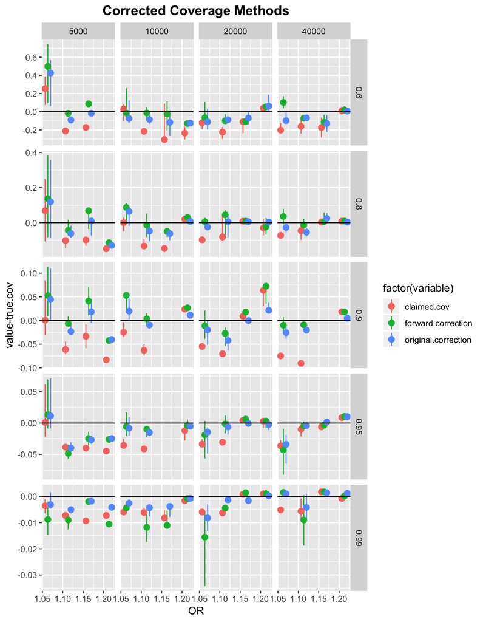

### Next Steps

- Find which GAM method is the quickest and best (currently running simulation in `quickerGAMmethods` directory on HPC to compare times).
- Set up simulations using this method with a larger number of repetitions and compare to original correction (can follow forward_method/new.R/ procedure).
- Investigate the back estimation approach using the chosen GAM method.